# Statistiques descriptives

**Table des matières:**

- I. Notions préliminaires
  - a. Vocabulaire
  - b. Application de ces concepts
- II. Types de variables et représentations
  - a. Types de variables
  - b. Variables qualitatives : représentations
  - c. Variables quantitatives : représentations
- III. Définition formelle de statistiques univariées
  - a. Variables quantitatives discrètes - effectifs et fréquences
  - b. Variables quantitatives - indicateurs de tendance centrale, de dispersion et de forme
  - c. Représentations de statistiques univariées

## I. Notions préliminaires

### a. Vocabulaire

- **Population**
  - Ensemble des individus ou des objets d'intérêt
- **Echantillon**
  - Seulement une partie de la population d'intérêt
- **Echantillon aléatoire**
  - Seulement une partie de la population d'intérêt, dont les individus ont été choisis au hasard
- **Echantillon représentatif**
  - Seulement une partie de la population d'intérêt, qui la représente fidèlement
- **Paramètre**
  - Une valeur qui concerne une population
- **Statistique**
  - Une valeur qui concerne un échantillon

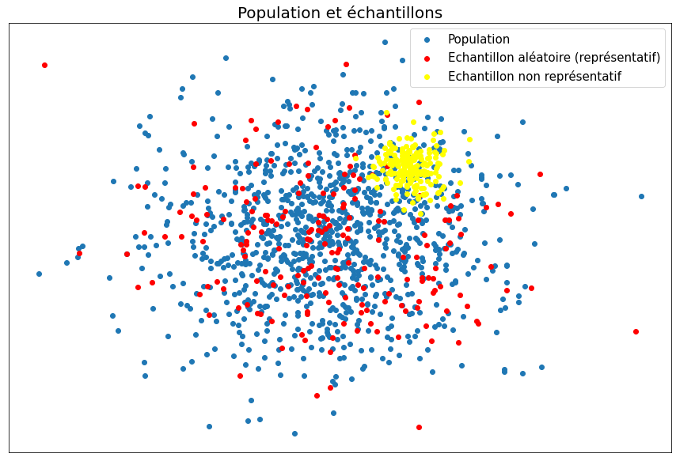

```python
import matplotlib.pyplot as plt
import numpy as np
plt.figure(figsize=(15,10))

_ = np.random.normal(0,1,1000)
__ = np.random.normal(0,1,1000) * 5 + 1
plt.scatter(_, __, label="Population")

_ = np.random.normal(0,1,200)
__ = np.random.normal(0,1,200) * 5 + 1
plt.scatter(_, __, color="red", label="Echantillon aléatoire (représentatif)")

_ = np.random.normal(1,1/4,200)
__ = np.random.normal(1,1/4,200) * 5 + 1
plt.scatter(_, __, color="yellow", label="Echantillon non représentatif")

# for minor ticks
#ax.set_xticks([], minor=True)


# for minor ticks
plt.gca().xaxis.set_major_locator(plt.NullLocator())
plt.gca().yaxis.set_major_locator(plt.NullLocator())
plt.legend(fontsize=15)

plt.title("Population et échantillons", fontsize=20)

plt.show()
```

## II. Types de variables et représentations

### a. **Types de variables**

- **Variable catégorielle ou qualitative**
  - Une variable qui est une catégorie : la couleur des yeux pour un humain, la marque pour une voiture...
  - Les différentes valeurs possibles sont appelées les modalités
    - **Nominale** :
      - Ne dépend pas d'un ordre, par exemple la couleur des yeux
    - **Ordinale** :
      - Les valeurs peuvent être ordonnées, par exemple : mauvais / moyen / bien / très bien
- **Variable numérique ou quantitative**
  - Une variable qui est une valeur, un nombre. Peut être continue ou discrète
    - **Variable discrète**
      - On peut énumérer toutes les valeurs possibles : le nombre de personnes dans une salle, le nombre d'années d'études
    - **Variable continue**
      - Peut prendre n'importe quelle valeur entre deux bornes : la taille d'un humain, la vitesse du vent

#### **Un exemple : le dataset "diamonds"**

- Documentation du dataset : https://www2.stat.duke.edu/courses/Fall15/sta112.01/post/hw/HW1.html
- Quelques lignes au hasard :

|  | carat | cut | color | price |
| --- | --- | --- | --- | --- |
| 38747 | 0.35 | Ideal | G | 1044 |
| 37591 | 0.24 | Very Good | E | 485 |
| 38560 | 0.50 | Fair | G | 1035 |
| 49076 | 0.54 | Ideal | G | 2060 |
| 4753 | 1.21 | Ideal | I | 3686 |
| 44483 | 0.60 | Very Good | H | 1597 |
| 11527 | 1.07 | Ideal | F | 5027 |
| 26489 | 1.70 | Very Good | G | 16086 |
| 51427 | 0.77 | Good | G | 2373 |
| 23687 | 1.51 | Good | G | 11746 |

- carat et price :
  - variables quantitatives continues
- cut :
  - variable qualitative ordinale ('Fair' < 'Good' < 'Very Good' < 'Premium' < 'Ideal')
- color :
  - peut être vue comme nominale ou ordinale (couleurs différentes, mais bien ordonnées d'après la documentation)

```python
import pandas as pd
import matplotlib.pyplot as plt
import numpy as np

#plt.style.use('seaborn-paper')

df = pd.read_csv('data/mtcars.csv')
diamonds = pd.read_csv('data/diamonds.csv').drop("Unnamed: 0", axis=1)

#print(diamonds[["carat", "cut", "color", "price"]].sample(10).to_html())
```

### b. **Variables qualitatives : représentations**

- On représente généralement :
  - **Effectifs** : Nombres d'occurences des modalités
  - **Fréquences** : Nombres d'occurences des modalités divisés par l'effectif total

#### **Table des effectifs**

|  | cut |
| --- | --- |
| Fair | 1610 |
| Good | 4906 |
| Very Good | 12082 |
| Premium | 13791 |
| Ideal | 21551 |

```python
# print(pd.DataFrame(diamonds['cut'].value_counts(ascending=True)).to_html())
```

#### **Table des fréquences**

|  | cut |
| --- | --- |
| Ideal | 39.95% |
| Premium | 25.57% |
| Very Good | 22.40% |
| Good | 9.10% |
| Fair | 2.98% |

```python
# print(pd.DataFrame(pd.DataFrame(diamonds['cut'].value_counts(ascending=False, normalize=True).map(lambda x: '{:.2%}'.format(x)))).to_html())
```

#### **Diagramme en batons (Bar Chart)**

[figure not shown]

[figure not shown]

```python
plt.figure(figsize=(10,5))
y_pos = np.arange(len(diamonds['cut'].unique()))
plt.bar(y_pos, diamonds['cut'].value_counts(), align = 'center')
plt.xticks(y_pos, diamonds['cut'].unique(), fontsize=15)
plt.xlabel('Cut', fontsize=15)
plt.ylabel('Effectif', fontsize=15)
plt.title('Variable Cut - Bar Chart (Effectifs)', fontsize=20)

plt.show()

plt.figure(figsize=(10,5))
y_pos = np.arange(len(diamonds['color'].unique()))
plt.bar(y_pos, diamonds['color'].value_counts(normalize=True), align = 'center')
plt.xticks(y_pos, diamonds['color'].unique(), fontsize=15)
plt.xlabel('Color', fontsize=15)
plt.ylabel('Fréquence', fontsize=15)
plt.title('Variable Color - Bar Chart (Fréquences)', fontsize=20)

plt.show()
```

#### **Diagramme circulaire / Camembert (Pie Chart)**

[figure not shown]

[figure not shown]

```python
import matplotlib as mpl
mpl.rcParams['font.size'] = 15

plt.figure(figsize=(10,10))
plt.pie(diamonds['color'].value_counts(), labels = diamonds['color'].unique(), autopct='%1.2f%%')
plt.title('Variable Color - Pie Chart', fontsize=20)
plt.show()

plt.figure(figsize=(10,10))
plt.pie(diamonds['cut'].value_counts(), labels = diamonds['cut'].unique(), autopct='%1.2f%%')
plt.title('Variable Cut - Pie Chart', fontsize=20)
plt.show()
```

#### **Diagramme de Pareto**

[figure not shown]

```python
values = diamonds['cut'].value_counts()
labels = np.arange(len(diamonds['cut'].unique()))

yvalues = []
xvalues = range(len(diamonds['cut'].unique()))

tmp = 0
for x in diamonds['cut'].value_counts():
    tmp += x/len(diamonds)
    yvalues.append(tmp)


fig, ax1 = plt.subplots()
ax2 = ax1.twinx()

ax1.bar(labels, values, align = 'center')
ax1.set_ylabel('Effectif')
ax2.plot(xvalues, yvalues, color = 'orange', linewidth = 2, linestyle = '-')
ax2.set_ylim(0,1)
ax2.set_ylabel('Fréquence cumulée')
plt.xticks(labels, diamonds['cut'].unique())
plt.title('Variable Cut Diagramme de Pareto')

plt.show()
```

#### **Table de contingence (effectifs)**

| cut color | Fair | Good | Ideal | Premium | Very Good | All |
| --- | --- | --- | --- | --- | --- | --- |
| D | 163 | 662 | 2834 | 1603 | 1513 | 6775 |
| E | 224 | 933 | 3903 | 2337 | 2400 | 9797 |
| F | 312 | 909 | 3826 | 2331 | 2164 | 9542 |
| G | 314 | 871 | 4884 | 2924 | 2299 | 11292 |
| H | 303 | 702 | 3115 | 2360 | 1824 | 8304 |
| I | 175 | 522 | 2093 | 1428 | 1204 | 5422 |
| J | 119 | 307 | 896 | 808 | 678 | 2808 |
| All | 1610 | 4906 | 21551 | 13791 | 12082 | 53940 |

```python
# print(pd.crosstab(diamonds['color'], diamonds['cut'], margins = True).to_html())
```

#### **Table de contingence (fréquences)**

| cut color | Fair | Good | Ideal | Premium | Very Good | All |
| --- | --- | --- | --- | --- | --- | --- |
| D | 0.30% | 1.23% | 5.25% | 2.97% | 2.80% | 12.56% |
| E | 0.42% | 1.73% | 7.24% | 4.33% | 4.45% | 18.16% |
| F | 0.58% | 1.69% | 7.09% | 4.32% | 4.01% | 17.69% |
| G | 0.58% | 1.61% | 9.05% | 5.42% | 4.26% | 20.93% |
| H | 0.56% | 1.30% | 5.77% | 4.38% | 3.38% | 15.39% |
| I | 0.32% | 0.97% | 3.88% | 2.65% | 2.23% | 10.05% |
| J | 0.22% | 0.57% | 1.66% | 1.50% | 1.26% | 5.21% |
| All | 2.98% | 9.10% | 39.95% | 25.57% | 22.40% | 100.00% |

```python
# print(pd.crosstab(diamonds['color'], diamonds['cut'], margins = True, normalize=True).applymap(lambda x: '{:.2%}'.format(x)).to_html())
```

### **Variables quantitatives : représentations**

#### **Histogrammes**

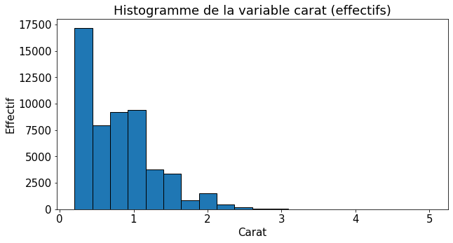

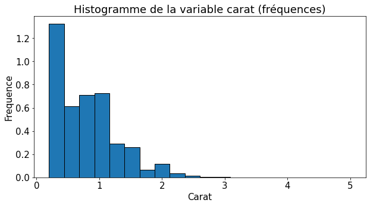

```python
plt.figure(figsize=(10,5))
plt.hist(diamonds['carat'], bins = 20,  edgecolor="black")
plt.xlabel('Carat')
plt.ylabel('Effectif')
plt.title('Histogramme de la variable carat (effectifs)')
plt.show()


plt.figure(figsize=(10,5))
plt.hist(diamonds['carat'], bins = 20, density=True, edgecolor="black")
plt.xlabel('Carat')
plt.ylabel('Frequence')
plt.title('Histogramme de la variable carat (fréquences)')
plt.show()
```

#### **Nuages de points (Scatter plot)**

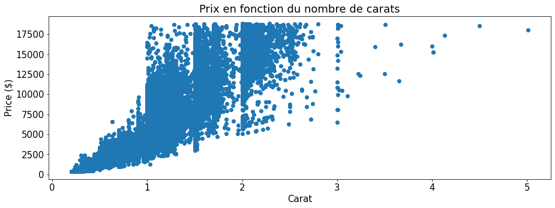

```python
plt.figure(figsize=(15,5))
plt.xlabel("Carat")
plt.ylabel("Price ($)")
plt.title("Prix en fonction du nombre de carats")
plt.scatter(diamonds.carat, diamonds.price)
plt.show()
```

## III. Définition formelle de statistiques univariées

### Notations

- On considère une variable statistique X, observée sur n individus. On dispose alors d’une série statistique unidimensionnelle que l’on peut mettre sous forme d’un tableau de données
- On note $x_i$ la valeur pour l'individu $i$

| individu | 1 | 2 | 3 | 4 | 5 | 6 | 7 | ... | n |
| --- | --- | --- | --- | --- | --- | --- | --- | --- | --- |
| valeur | $x_1$ | $x_2$ | $x_3$ | $x_4$ | $x_5$ | $x_6$ | $x_7$ | ... | $x_n$ |

### a. Variables quantitatives discrètes - effectifs et fréquences

- Dans la suite, on utilisera comme exemple la série $X$ suivante (série de notes sur 20) :

  | individu | 1 | 2 | 3 | 4 | 5 | 6 | 7 | 8 |
  | --- | --- | --- | --- | --- | --- | --- | --- | --- |
  | valeur | 12 | 10 | 8 | 15 | 5 | 10 | 12 | 8 |

- On a donc $x_1 = 12, x_2 = 10 ...$

### Effectifs

- **Généralités**
  - En classant les valeurs par ordre croissant, on notera $n_i$ l'effectif de la ième valeur, c'est à dire le nombre d'individus ayant cette valeur
  - On notera $n$ l'effectif total
  - En notant $p$ le nombre de valeur distinctes, on a donc : $n = n_1 + n_2 + ... + n_p$
  - Que l'on peut réécrire : $ n = \sum_{i=1}^{p} n_i $
- **Exemple**

| $i$ | 0 | 1 | 2 | 3 | 4 |
| --- | --- | --- | --- | --- | --- |
| valeur | 5 | 8 | 10 | 12 | 15 |
| effectif | 1 | 2 | 2 | 2 | 1 |

- On remarque qu'on a bien $n_1 + n_2 + n_3 + n_4 + n_5 = 1 + 2 + 2 + 2 + 1 = 8$ et $n$ = 8.

### Effectifs cumulés

- **Généralités**
  - Toujours en classant les valeurs $x_i$, on peut définir l'effectif cumulé $N_i$ comme étant la somme des effectifs pour les valeurs plus petites que $x_i$ (donc pour $j$ < $i$)
  - On a donc : $ N_i = \sum_{j=1}^{i}n_j $
  - Aussi, l'effectif cumulé de la dernière valeur est égal au nombre de valeurs : $N_p = \sum_{j=1}^{p} n_j = n$
- **Exemple**
- $N_3 = \sum_{j=1}^{3} n_j = 1 + 2 + 2 = 5$
- $N_p = N_5 = \sum_{j=1}^{5} n_j = 1 + 2 + 2 + 2 + 1 = 8 (=n)$

| $i$ | 1 | 2 | 3 | 4 | 5 |
| --- | --- | --- | --- | --- | --- |
| valeur | 5 | 8 | 10 | 12 | 15 |
| effectif : $n_i$ | 1 | 2 | 2 | 2 | 1 |
| effectif cumulé : $N_i$ | 1 | 3 | 5 | 7 | 8 |

### Fréquences

- **Généralités**
  - En classant les valeurs par ordre croissant, on notera $f_i$ l'effectif de la valeur $i$ (= la proportion d'individus ayant cette valeur)
  - On a donc : $$f_i = \frac{n_i}{n}$$
  - En notant $p$ le nombre de valeur distinctes, on a donc : $f_1 + f_2 + ... + f_p = 1$ (les fréquences somment à 1)
  - Que l'on peut réécrire : $ 1 = \sum_{i=1}^{p} f_i $
- **Exemple**

| $i$ | 1 | 2 | 3 | 4 | 5 |
| --- | --- | --- | --- | --- | --- |
| valeur | 5 | 8 | 10 | 12 | 15 |
| effectif : $n_i$ | 1 | 2 | 2 | 2 | 1 |
| fréquence : $f_i$ | 0.125 | 0.25 | 0.25 | 0.25 | 0.125 |
| fréquence cumulée : $F_i$ | 0.125 | 0.375 | 0.625 | 0.875 | 1 |

On remarque qu'on a bien $f_1 + f_2 + f_3 + f_4 + f_5 = 1$

### Fréquences cumulées

- **Généralités**
  - Toujours en classant les valeurs $x_i$, on peut définir la fréquence cumulée $F_i$ comme étant la somme des fréquences pour les valeurs plus petites que $x_i$ (donc pour $j$ < $i$)
  - On a donc : $$ F_i = \sum_{j=1}^{i}f_j $$
  - Que l'on peut réécrire : $$F_i = \sum_{j=1}^{i}\frac{n_j}{n} $$
  - Aussi, la fréquence cumulée de la dernière valeur est égal à 1 : $F_p = \sum_{j=1}^{p} f_j = 1$
- **Exemple**
- $F_3 = \sum_{j=1}^{3} f_j = 0.125 + 0.25 + 0.25 = 0.625$
- $F_p = F_5 = 1$

| $i$ | 1 | 2 | 3 | 4 | 5 |
| --- | --- | --- | --- | --- | --- |
| valeur | 5 | 8 | 10 | 12 | 15 |
| effectif : $n_i$ | 1 | 2 | 2 | 2 | 1 |
| fréquence : $f_i$ | 0.125 | 0.25 | 0.25 | 0.25 | 0.125 |
| fréquence cumulée : $F_i$ | 0.125 | 0.375 | 0.625 | 0.875 | 1 |

```python
df = pd.DataFrame([1, 2, 3, 4, 5, 6, 7, "...", "n"], columns=["individu"])

df.set_index("individu", inplace=True, drop=True)

df["valeur"] =  df.index.to_series().astype(str).map(lambda x: "$x_"+x + "$" if x!='...' else x)

#print(df.T.to_html())


df = pd.DataFrame([1, 2, 3, 4, 5, 6, 7, 8], columns=["individu"])

df.set_index("individu", inplace=True, drop=True)

df.index = df.index.to_series().astype(str)


df["valeur"] =  [12, 10, 8, 15, 5, 10 , 12 , 8]

#print(df.T.to_html())


df["effectif : $n_i$"] = 1
df = df.groupby("valeur").count()

df["$i$"] = range(1, df.shape[0] + 1)

df["valeur"] = df.index

df.set_index("$i$", inplace=True)

df["effectif cumulé : $N_i$"] = df["effectif : $n_i$"].cumsum()
#print(df[["valeur", "effectif : $n_i$", "effectif cumulé : $N_i$"]].T.to_html())



df = pd.DataFrame([1, 2, 3, 4, 5, 6, 7, 8], columns=["individu"])

df.set_index("individu", inplace=True, drop=True)

df.index = df.index.to_series().astype(str)


df["valeur"] =  [12, 10, 8, 15, 5, 10 , 12 , 8]

#print(df.T.to_html())


df["effectif : $n_i$"] = 1
df = df.groupby("valeur").count()

df["$i$"] = range(1, df.shape[0] + 1)

df["valeur"] = df.index

df.set_index("$i$", inplace=True)

df["effectif cumulé : $N_i$"] = df["effectif : $n_i$"].cumsum()
#print(df[["valeur", "effectif : $n_i$", "effectif cumulé : $N_i$"]].T.to_html())


df["fréquence : $f_i$"] = df["effectif : $n_i$"] / 8


df["effectif : $n_i$"] = df["effectif : $n_i$"].astype(int).astype(str)

df["$i$"] = df.index

#print(df[["$i$", "valeur",  "effectif : $n_i$", "fréquence : $f_i$",]].T.to_html(justify="right"))


df["fréquence cumulée : $F_i$"] = df["fréquence : $f_i$"].cumsum().astype(str).str.replace("1.0", "1")

#print(df[["$i$", "valeur",  "effectif : $n_i$", "fréquence : $f_i$", "fréquence cumulée : $F_i$"]].T.to_html(justify="right"))
```

### b. Variables quantitatives - indicateurs de tendance centrale, de dispersion et de forme

#### Définitions

- **indicateurs de tendance centrale** : les statistiques qui fournissent l'ordre de grandeur des valeurs de la série et la position où se rassemblent ces valeurs.
- **indicateurs de dispersion** : les statistiques qui quantifient les fluctuations des valeurs autour de la valeur centrale. Permettent d'apprécier l'étalement des valeurs de la série (les unes par rapport aux autres ou à la valeur centrale).
- **indicateurs de forme** : donnent une idée de la symétrie et de l'aplatissement d'une distribution. Leur usage est moins fréquent.

#### Moyenne arithmétique

##### Généralités

- La moyenne arithmétique est la moyenne telle que vous la connaissez. C'est un indicateur de tendance centrale.
- On la note généralement $\bar{x}$
- On la calcule en sommant toutes les valeurs $x_i$ et en divisant par le nombre d'individus $n$. Donc :

$$ \bar{x} = \frac{1}{n}\sum_{i=1}^{n}x_i $$

- Si l'on a $p$ valeurs distinctes et qu'on connait les effectifs $n_j$ pour chacune des valeurs distinctes, on peut aussi la calculer ainsi :

$$ \bar{x} = \frac{1}{n} \sum_{j=1}^{p}n_j x_j $$

- Qui peut aussi s'écrire en utilisant les fréquences au lieu des effectifs (car $f_j = n_j / n$) : $$ \bar{x} = \sum_{j=1}^{p}f_j x_j $$

##### Exemple

- Considérons la série de valeurs suivante :

| individu | 1 | 2 | 3 | 4 | 5 | 6 | 7 | 8 |
| --- | --- | --- | --- | --- | --- | --- | --- | --- |
| valeur | 12 | 10 | 8 | 15 | 5 | 10 | 12 | 8 |

- La moyenne vaut : $\frac{1}{8}\times(12 + 8 + 10 + 15 + 5 + 10 + 12 + 8) = \frac{80}{8} = 10$

| $i$ | 0 | 1 | 2 | 3 | 4 |
| --- | --- | --- | --- | --- | --- |
| valeur | 5 | 8 | 10 | 12 | 15 |
| effectif | 1 | 2 | 2 | 2 | 1 |

- Avec les effectifs : $\frac{1}{8}\times(5 \times 1 + 8 \times 2 + 10 \times 2 + 12 \times 2 + 15 \times 1) = \frac{80}{8} = 10$

#### Médiane :

##### Généralités

- C'est la valeur telle qu'il y a autant de valeur plus petites que de valeurs plus grandes. C'est un indicateur de tendance centrale. Contrairement à la moyenne qui être très sensible aux valeurs extrêmes, la médiane ne l'est pas - on dit qu'elle est plus robuste.
- On note la médiane $x_{1/2}$
- Si le nombre de valeurs est impair, c'est la valeur au milieu lorsqu'on les classe par ordre croissant
- Si le nombre de valeurs est pair, il n'y a pas de valeurs au milieu : on prend donc la moyenne entre les deux valeurs centrales

##### Exemple

- On a classé les notes de la série d'exemple par ordre croissant :

  | individu | 5 | 3 | 8 | 2 | 6 | 1 | 7 | 4 |
  | --- | --- | --- | --- | --- | --- | --- | --- | --- |
  | valeur | 5 | 8 | 8 | 10 | 10 | 12 | 12 | 15 |

- Les deux valeurs au milieu sont 10 et 10, on prend donc leur moyenne qui est aussi égale à 10. Donc :

$$ x_{1/2} = 10 $$

- On a supprimé le 8ème élève (pour avoir un nombre impair ) et classé les notes de la série d'exemple par ordre croissant :

  | individu | 5 | 3 | 2 | 6 | 1 | 7 | 4 |
  | --- | --- | --- | --- | --- | --- | --- | --- |
  | valeur | 5 | 8 | 10 | 10 | 12 | 12 | 15 |

- La valeur du milieu est 10 donc : $ x_{1/2} = 10 $

#### Mode :

##### Généralités :

- Le mode est aussi un indicateur de centralité. C'est la valeur la plus observée dans une série de valeurs. Elle n'est pas forcément unique. On peut la déterminer en regardant la table des effectifs pour une variable quantitative discrète.

##### Exemple :

| $i$ | 0 | 1 | 2 | 3 | 4 |
| --- | --- | --- | --- | --- | --- |
| valeur | 4 | 9 | 16 | 18 | 19 |
| effectif | 1 | 2 | 5 | 2 | 2 |

- Dans cette série le mode est 16 avec un effectif de 5

#### Variance et écart-type :

##### Généralités

- La variance et l'écart type sont des indicateurs de dispersion
- La variance est définie comme la moyenne des "écarts à la moyennes" au carré. Pour une valeur $x_i$, l'écart à la moyenne est : $(x_i - \bar{x})$ et on prend la moyenne du carrée de ces valeurs donc :

$$ Var(x) = \frac{1}{n} \sum_{i=1}^{n} (x_{i} - \bar{x})^2 $$

- On admettra qu'on peut aussi calculer la variance ainsi :

$$ Var(x) = (\frac{1}{n} \sum_{i=1}^{n}x_{i}^2) - (\bar{x}^2) $$

- L'écart-type est défini comme la racine de la quantité précédente, on le note $ \sigma_{x} $ :

$$ \sigma_{x} = \sqrt{Var(x)}$$$$ \sigma_{x} = \sqrt{\frac{1}{n} \sum_{i=1}^{n} (x_{i} - \bar{x})^2}$$

- On note généralement la variance $\sigma_{x}^{2}$ puisque comme l'écart-type est la racine de la variance, alors la variance est le carré de l'écart-type

##### Exemple

- La moyenne $\bar{x}$ vaut 10. On a calculer les écarts à le moyenne $(x_{i} - \bar{x})$ puis leurs carrés $(x_{i} - \bar{x})^2$

|  | 1 | 2 | 3 | 4 | 5 | 6 | 7 | 8 |
| --- | --- | --- | --- | --- | --- | --- | --- | --- |
| $x_i$ | 12 | 10 | 8 | 15 | 5 | 10 | 12 | 8 |
| $(x_i - \overline{x})$ | 2 | 0 | -2 | 5 | -5 | 0 | 2 | -2 |
| $(x_i - \overline{x} )^2$ | 4 | 0 | 4 | 25 | 25 | 0 | 4 | 4 |

- Donc : $ Var(x) = (4 + 0 + 4 + 25 + 25 + 0 + 4 + 4) / 8 = 66 / 8 = 8.25 $
- Et : $\sigma_{x} = \sqrt{Var(x)} = \sqrt{8.25} = 2.87$

#### Coefficient de variation :

##### Généralités

- Le coefficient de variation est un indicateur de dispersion, plus précisément de dispersion relative. Il est le quotient de l'écart type par la moyenne. Une grande valeur indique que les valeurs sont très dispersées autour de la moyenne, une petite valeur indique les valeurs sont peu dispersées autour de la moyenne.
- On le note et calcule ainsi :

$$ CV_x = \frac{\sigma_x}{\bar{x}} $$

##### Exemple

- Si $\bar{x} = 10$ et $\sigma_{x} = 2.87$ alors $CV = \frac{\sigma_x}{\bar{x}} = 0.287$
- L'écart-type représente 28.7 % de la valeur de la moyenne

```python
df = pd.DataFrame([1, 2, 3, 4, 5, 6, 7, "...", "n"], columns=["individu"])

df.set_index("individu", inplace=True, drop=True)

df["valeur"] =  df.index.to_series().astype(str).map(lambda x: "$x_"+x + "$" if x!='...' else x)

#print(df.T.to_html())


df = pd.DataFrame([1, 2, 3, 4, 5, 6, 7, 8], columns=[" " * 20])

df.set_index(" " * 20, inplace=True, drop=True)

df.index = df.index.to_series().astype(str)


df["$x_i$"] =  [12, 10, 8, 15, 5, 10 , 12 , 8]

#print(df.sort_values("valeur").T.to_html())

#df
df["$(x_i - \overline{x})$"] = (df["$x_i$"] - df["$x_i$"].mean()).astype(int)

df["$(x_i -  \overline{x} )^2$"] = (df["$x_i$"] - df["$x_i$"].mean()).map(lambda x: x**2).astype(int)

#print(df.T.to_html())

#print(df["$x_i$"].var())
```